# Descriptive Analyses SESOI PANAS

## Descriptives

We see the mean scores for the PA and NA differ. NA shows floor effects, the distributions are skewed. PA effects are a bit more varied and do not suffer from floor or ceiling effects.

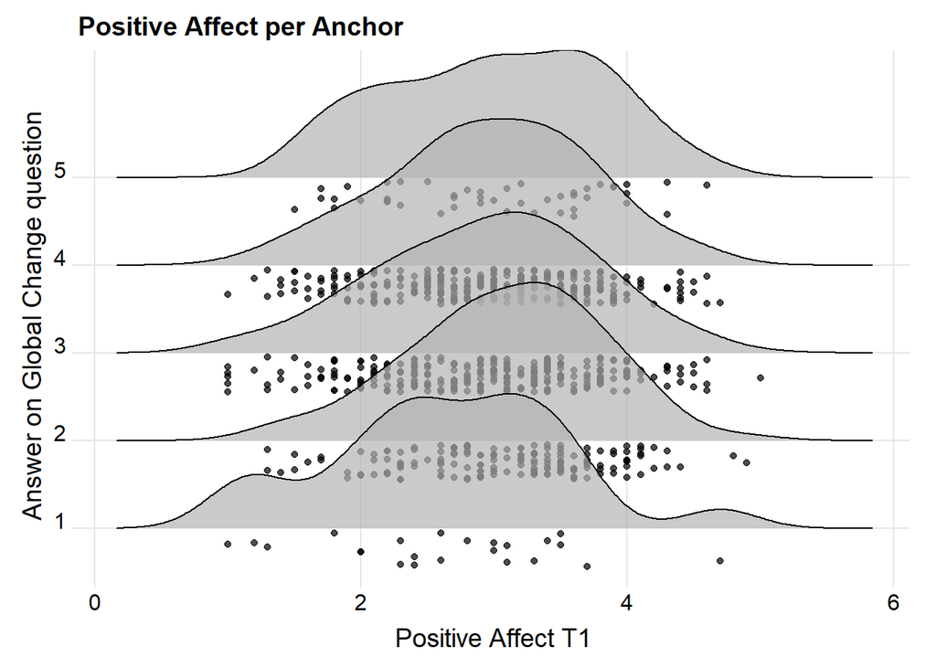

```r
#plot raw data
ggplot(PANASdata, aes(x = T1_PA, y = as.factor(globalPA))) +
  geom_density_ridges(jittered_points = TRUE, position = "raincloud", alpha = 0.7) +
  theme_ridges(center = TRUE) +
  labs(
    x = "Positive Affect T1",
    y = "Answer on Global Change question",
    title = "Positive Affect per Anchor")
```

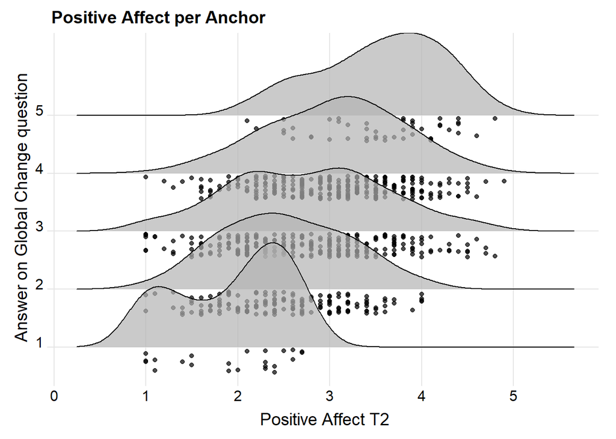

```r
ggplot(PANASdata, aes(x = T2_PA, y = as.factor(globalPA))) +
  geom_density_ridges(jittered_points = TRUE, position = "raincloud", alpha = 0.7) +
  theme_ridges(center = TRUE) +
  labs(
    x = "Positive Affect T2",
    y = "Answer on Global Change question",
    title = "Positive Affect per Anchor")
```

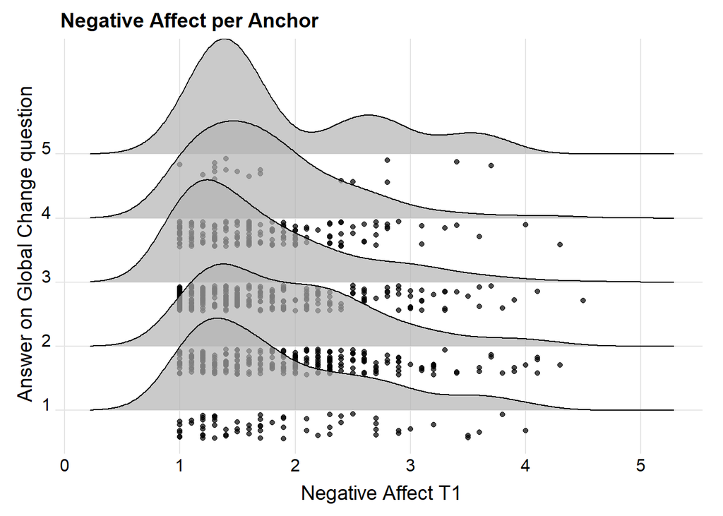

```r
ggplot(PANASdata, aes(x = T1_NA, y = as.factor(globalNA))) +
  geom_density_ridges(jittered_points = TRUE, position = "raincloud", alpha = 0.7) +
  theme_ridges(center = TRUE) +
  labs(
    x = "Negative Affect T1",
    y = "Answer on Global Change question",
    title = "Negative Affect per Anchor")
```

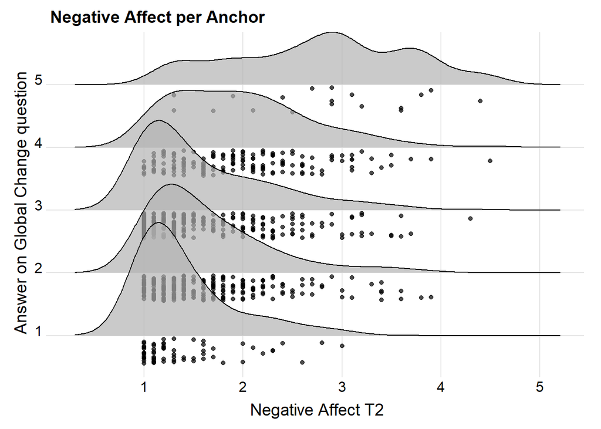

```r
ggplot(PANASdata, aes(x = T2_NA, y = as.factor(globalNA))) +
  geom_density_ridges(jittered_points = TRUE, position = "raincloud", alpha = 0.7) +
  theme_ridges(center = TRUE) +
  labs(
    x = "Negative Affect T2",
    y = "Answer on Global Change question",
    title = "Negative Affect per Anchor")
```

We will analyze the differences scores. It is important to remember that difference scores are calculated based on T2 - T1. So for PA, a score of 4 at T1 and 5 at T2 leads to a change score of 5-4 = 1. Thus, a positive score means PA changes in a positive direction - an increase of 1. For NA, a positive score means an increase in negative affect.

We can plot the distributions, as a function of each answer on the global transition question (from 1 to five, much less positive/negative, a little less positive/negative, the same, a little more positive/negative, and much more positive/negative).

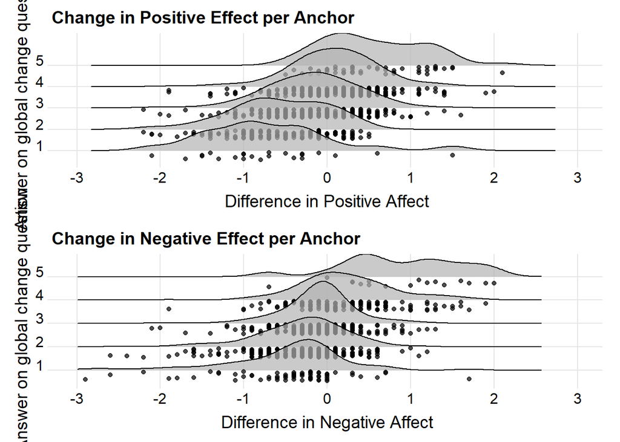

```r
#plot raw difference scores
p1 <- ggplot(PANASdata, aes(x = PA_change, y = as.factor(globalPA))) +
  geom_density_ridges(jittered_points = TRUE, position = "raincloud", alpha = 0.7) +
  theme_ridges(center = TRUE) +
  labs(
    x = "Difference in Positive Affect",
    y = "Answer on global change question",
    title = "Change in Positive Effect per Anchor") +
  scale_x_continuous(breaks = c(-3, -2, -1, 0, 1, 2, 3),
                     limits = c(-3, 3))

p2 <- ggplot(PANASdata, aes(x = NA_change, y = as.factor(globalNA))) +
  geom_density_ridges(jittered_points = TRUE, position = "raincloud", alpha = 0.7) +
  theme_ridges(center = TRUE) +
  labs(
    x = "Difference in Negative Affect",
    y = "Answer on global change question",
    title = "Change in Negative Effect per Anchor") +
   scale_x_continuous(breaks = c(-3, -2, -1, 0, 1, 2, 3),
                     limits = c(-3, 3))

grid.arrange(p1, p2, nrow = 2)
```

We see that there are not a lot of people who say they feel much less positive, or much more positive. Overall, the pattern is in the direction we expect - the change scores are positive if people indicate on the global question that they feel a little or much more negative or positive. Below is a plot of just the mean differences. This plot more clearly shows that the mean is not exactly 0 for the no change (3) group. Interestingly, both the positive as the negative change is slightly negative.

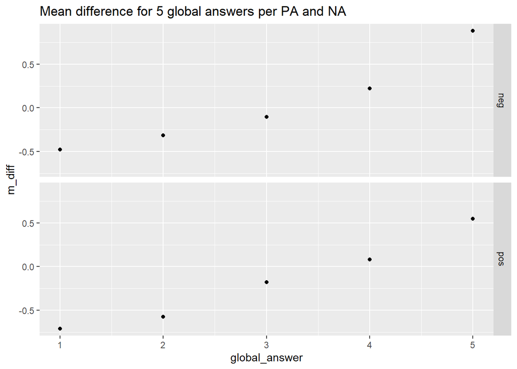

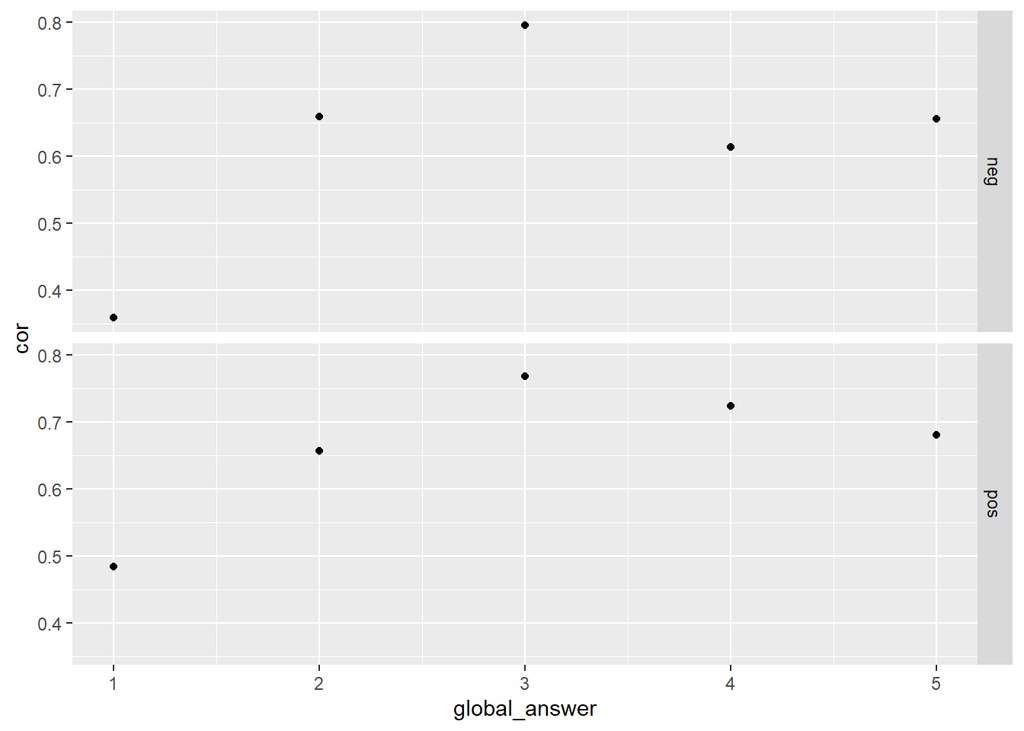

Correlations between T1 and T2 for Positive affect and Negative affect

```r
# Look at correlations `between pre and post measure, for each global anchor answer
# Correlation is highest for no change groups. This is important because the correlation
ggplot(data = sum_data, aes(x = global_answer, y = cor)) +
  stat_summary(aes(y = cor), fun = "mean", geom = "point") +
  facet_grid(PA_NA ~ .)
```

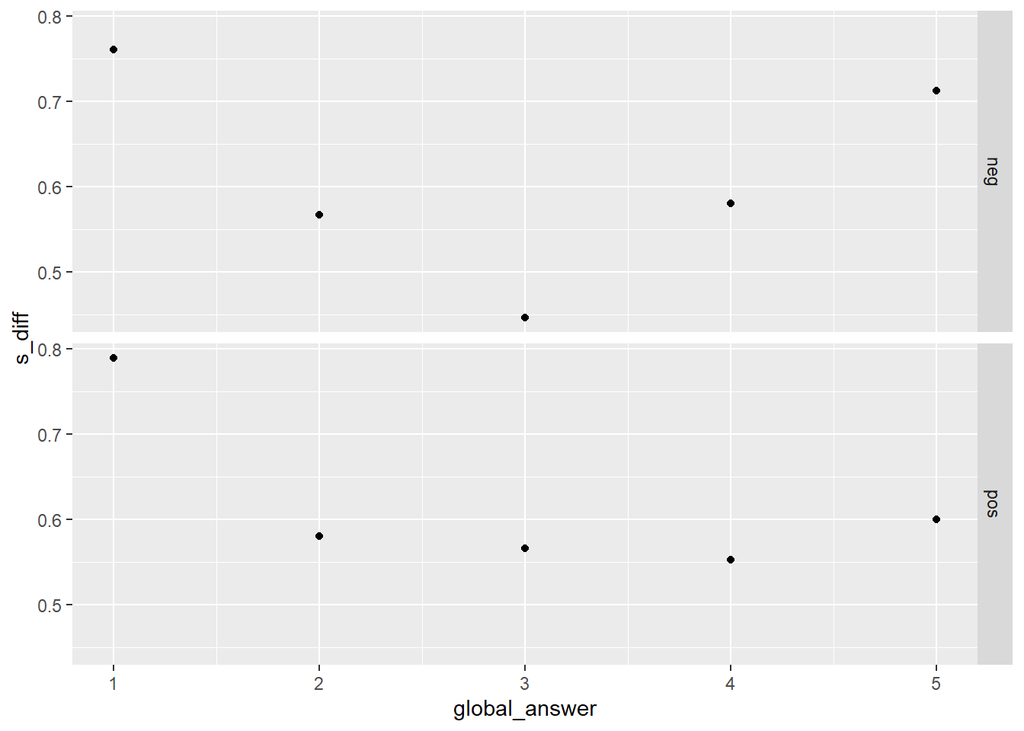

Standard deviation for difference scores between T1 and T2 for Positive affect and Negative affect

```r
ggplot(data=sum_data, aes(x = global_answer, y = s_diff)) +
  stat_summary(aes(y = s_diff), fun = "mean", geom = "point") +
  facet_grid(PA_NA ~ .)
```

# Plots per Cohort

We can examine our data by plotting it seperately for the 4 cohorts. 2018 and 2019 are 2 samples from the TU/e from different years. 2 and 5 are the prolific sample with 2 vs 5 days apart. The patterns are relatively similar, but the Prolific sample has a more general shoft across the days.

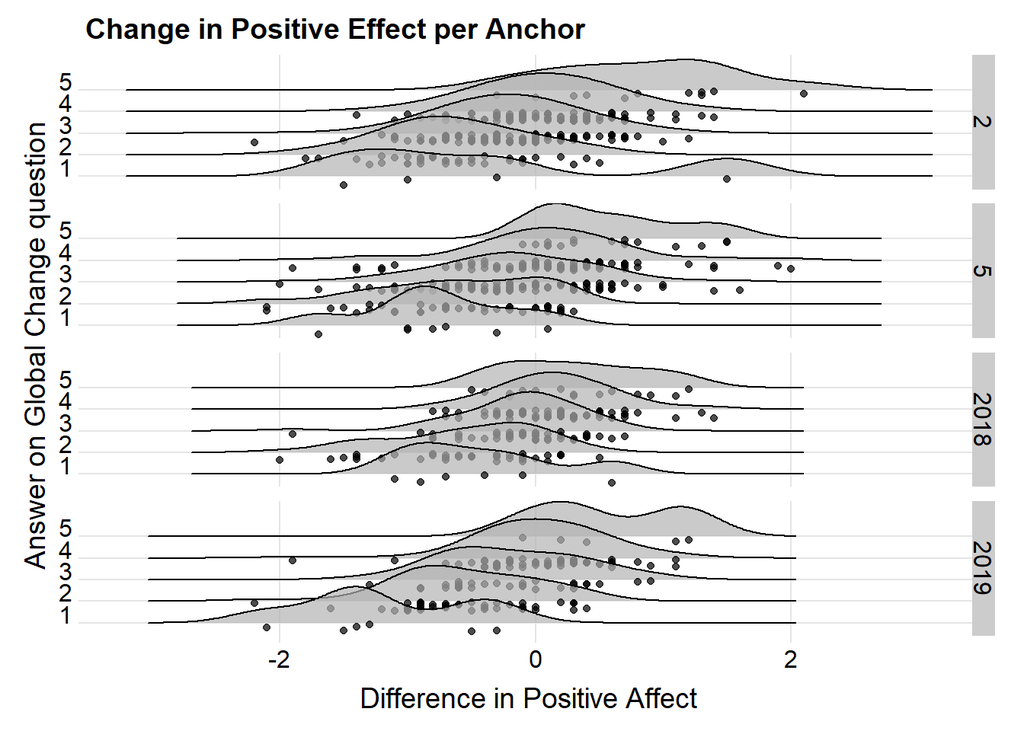

```r
ggplot(PANASdata, aes(x = PA_change, y = as.factor(globalPA))) +
  geom_density_ridges(jittered_points = TRUE, position = "raincloud", alpha = 0.7) +
  theme_ridges(center = TRUE) +
  labs(
    x = "Difference in Positive Affect",
    y = "Answer on Global Change question",
    title = "Change in Positive Effect per Anchor") +
  facet_grid(Cohort ~ .)
```

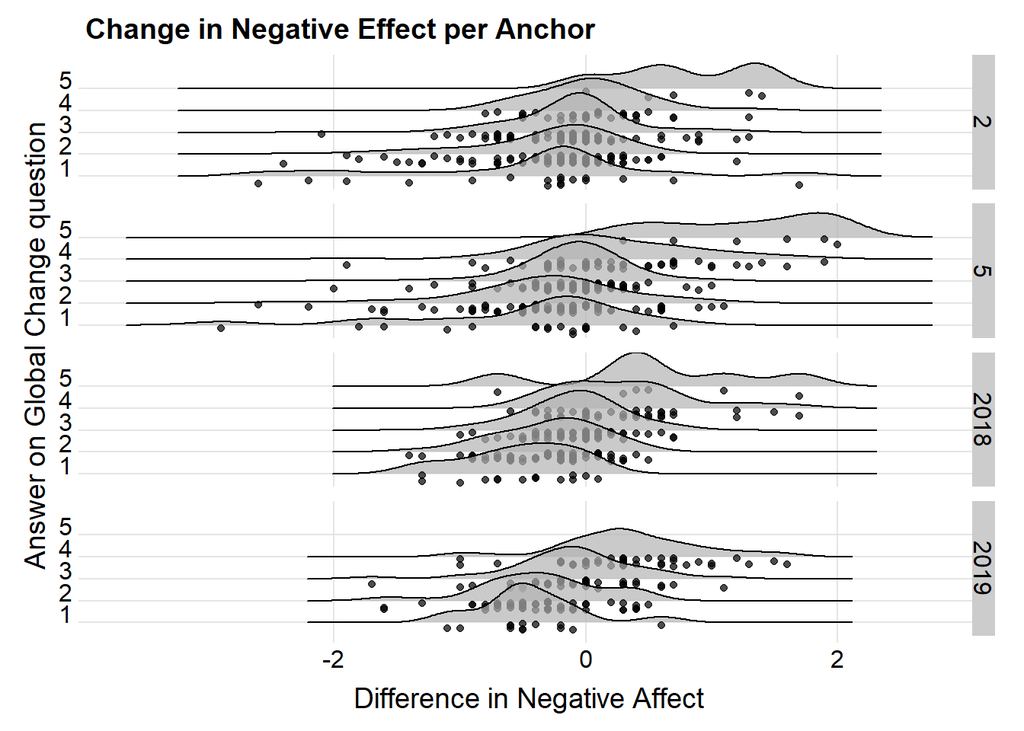

```r
ggplot(PANASdata, aes(x = NA_change, y = as.factor(globalNA))) +
  geom_density_ridges(jittered_points = TRUE, position = "raincloud", alpha = 0.7) +
  theme_ridges(center = TRUE) +
  labs(
    x = "Difference in Negative Affect",
    y = "Answer on Global Change question",
    title = "Change in Negative Effect per Anchor") +
  facet_grid(Cohort ~ .)
```

We can also examine the correlations for each subgroup by repeating the summary stats calculations above for each global answer, but then when selecting data from a single subgroup.

For the 2 day prolific group:

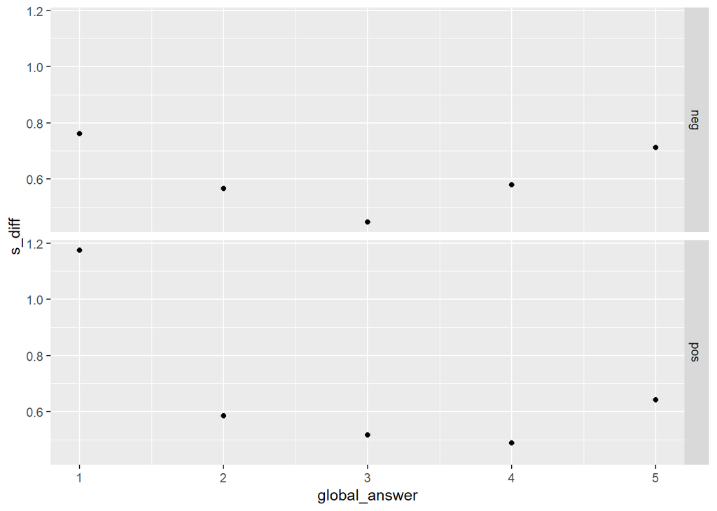

```r
ggplot(data=sum_data_cohort, aes(x = global_answer, y = s_diff)) +
  stat_summary(aes(y = s_diff), fun = "mean", geom = "point") +
  facet_grid(PA_NA ~ .)
```

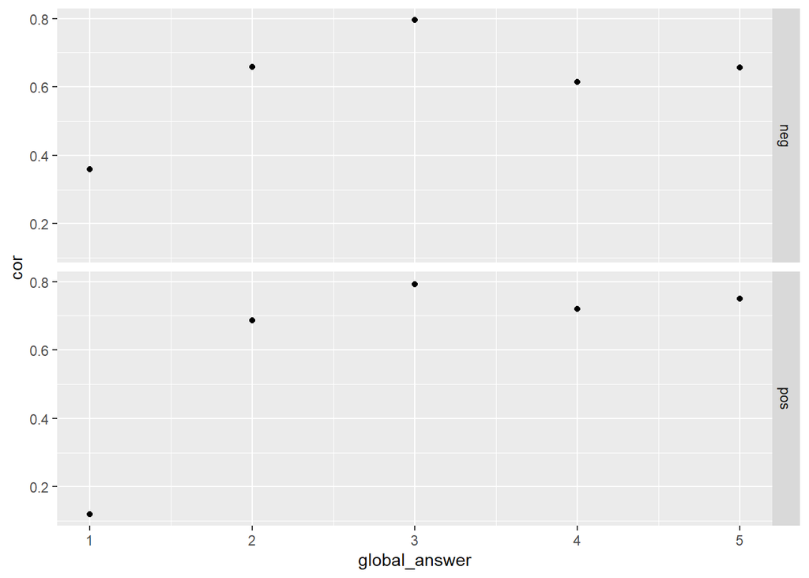

```r
ggplot(data=sum_data_cohort, aes(x = global_answer, y = cor)) +
  stat_summary(aes(y = cor), fun = "mean", geom = "point") +
  facet_grid(PA_NA ~ .)
```

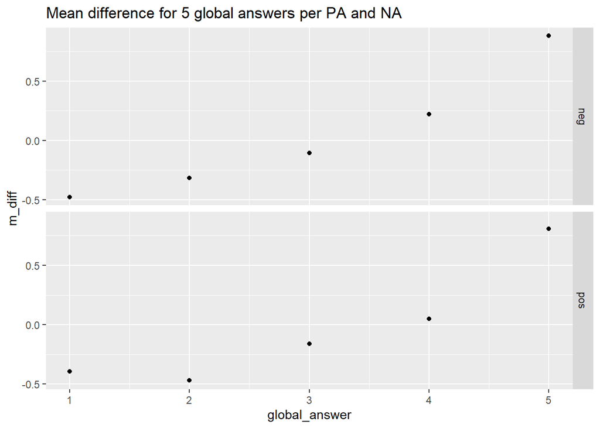

```r
ggplot(data=sum_data_cohort, aes(x = global_answer, y = m_diff)) +
  stat_summary(aes(y = m_diff), fun = "mean", geom = "point") +
  facet_grid(PA_NA ~ .) +
  ggtitle("Mean difference for 5 global answers per PA and NA")
```

For the 5 day prolific group:

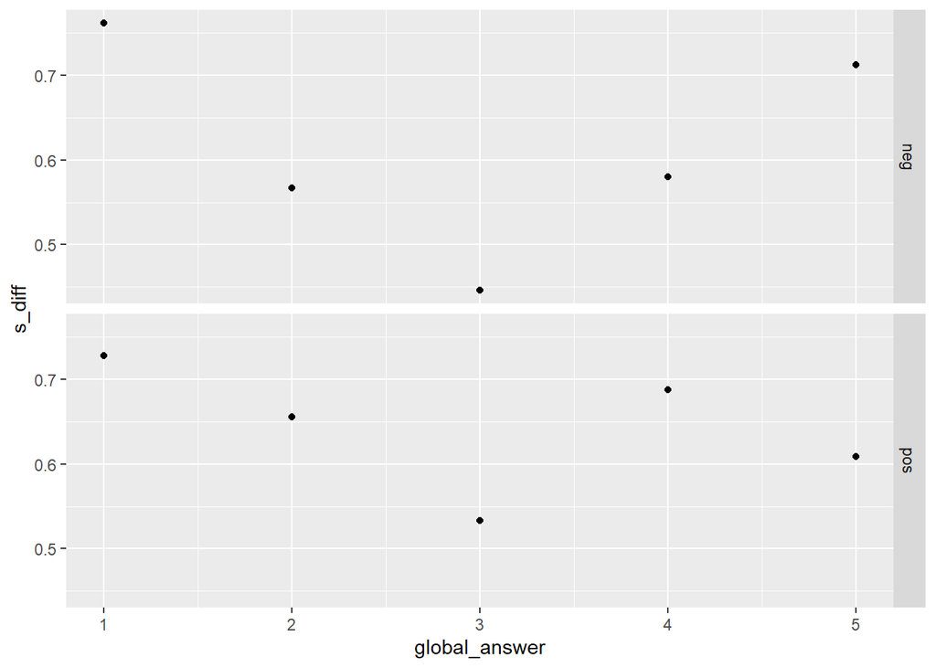

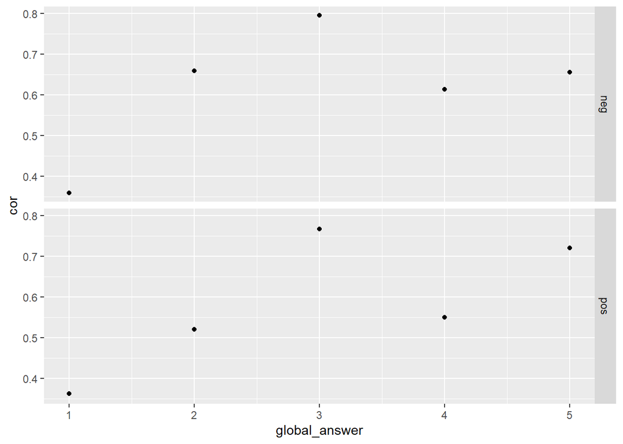

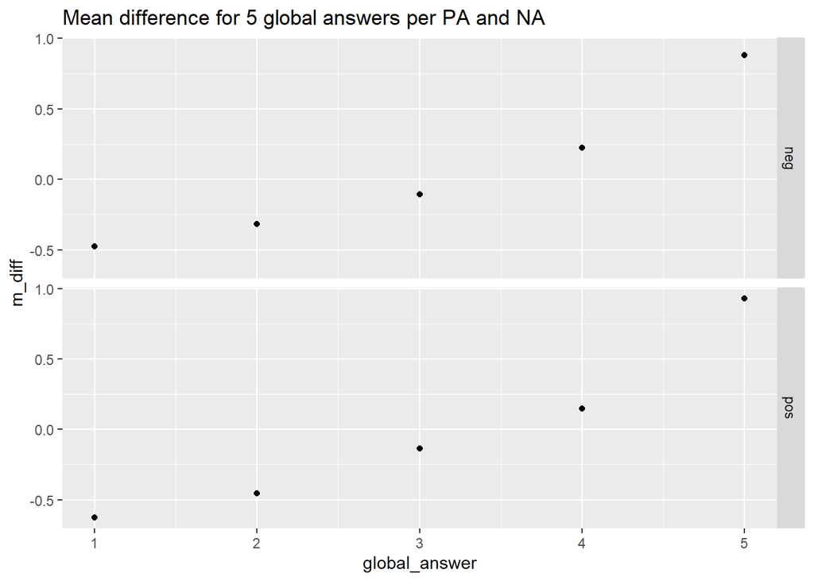